# Investigating the Body Masses of Arthropods

Justin Liu

## Abstract

In this study, we will investigate the relationship between the masses of arthropods to their body lengths, orders, and regions where they live. Through Welch’s *t*-test, we found that the mean of the logged body masses did not differ between temperate and tropical regions. We also fit a linear model with order and region as predictors, which was not a good fit of our data despite fulfilling all of the assumptions. Other linear models (mainly including body lengths) were fit but did not meet all of the assumptions. The main limitations of this study was using a relatively small sample size ($n = 250$) and using a simplistic linear regression model compared to more complicated models.

## Introduction

The data was retrieved from a study conducted by Sohlström et al. (2018) in which measurements of arthropods were recorded in order to find a model that could predict their body masses. Although predicting body mass is not new in ecology, the authors noted that there were not many studies done on measuring arthropods “covering a large range in body length, taxonomic groups, and multiple geographical regions” (p. 12737). Body mass has a close relation to body length, and studies like Benke et al. (1999) noted that this relationship could be represented by a power law $M = aL^b$, where $M$ is the body mass of an organism, $L$ is its body length, and $a$ and $b$ are constants (p. 309). I want to test if this relationship could also be represented through a linear model (which is easier to interpret) and if other predictors like temperature and order could improve the model. I also want to see if there is a difference in body mass for arthropods living in temperate (colder) vs. tropical (warmer) regions.

My main hypotheses are:

- There is a significant difference in body masses between arthropods living in temperate and tropical regions.
- The variables body length, order, and region have a significant effect on changes in body mass.

**Table 1.** The variables of interest in this study. The body mass is the response while the rest are predictors. There are 2 numeric variables and 2 categorical variables.

| Variable | Type |
| --- | --- |
| Body mass (mg) | Numeric |
| Body length (mm) | Numeric |
| Order | Categorical (*araneae* / *hemiptera*) |
| Region | Categorical (*temperate* / *tropical*) |

## Exploratory Data Analysis

In this section, we will conduct some exploratory data analysis on the variables of interest.

### Cleaning the dataset

Before we explore the data, we should be clear on how the dataset was cleaned and subsetted. In the following steps, it is important to note that each step yields a smaller subset of the data, which will further be touched upon in the discussion section.

1. Select the 4 columns of interest.
2. Omit any rows with missing data.
3. Keep only the rows corresponding to the top 2 common orders (i.e. *araneae* and *hemiptera*).
4. Randomly sample 250 rows to focus on.

### Distribution of body masses (numeric)

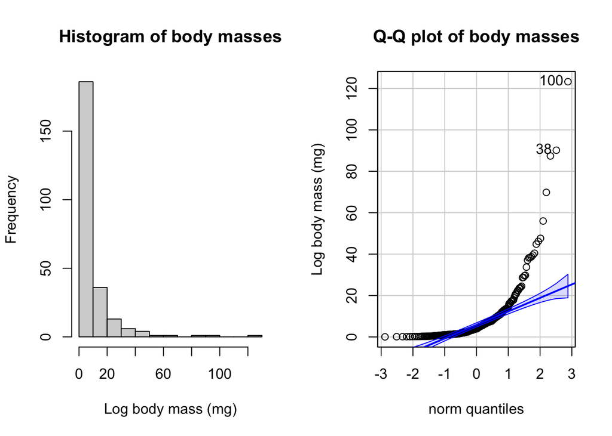

**Figure 1.** Histogram and Q-Q plot of the body masses (mg) of arthropods classified as *araneae* and *hemiptera* (n = 250).

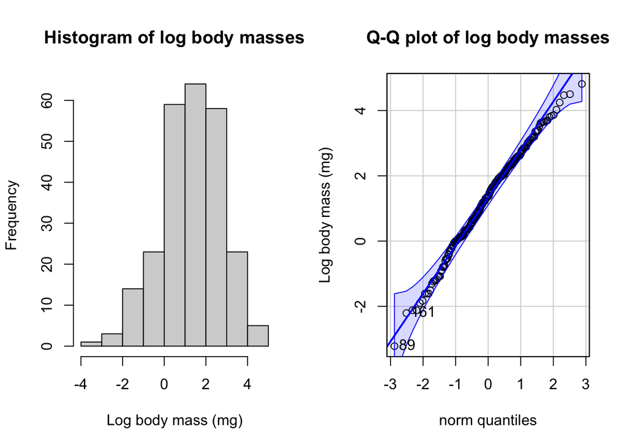

**Figure 2.** Histogram and Q-Q plot of the log-transformed body masses (mg) of *araneae* and *hemiptera* (n = 250).

### Relationship between body mass (numeric) and body length (numeric)

The body masses and body lengths appear to be positively correlated. In the scatterplot below (Figure 3), larger body lengths seem to correspond with larger body masses. However, this trend seems to be more curved than linear.

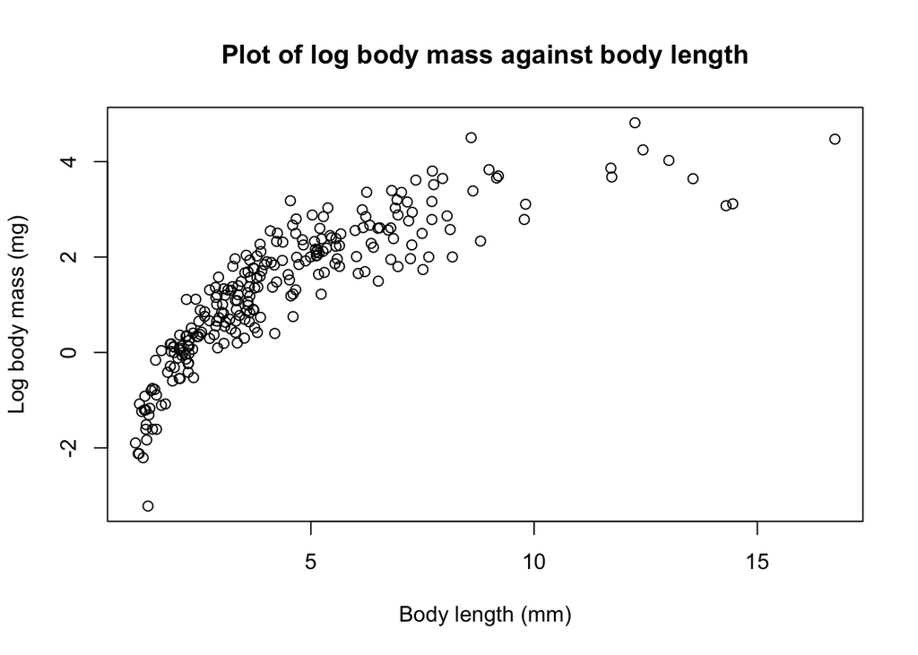

**Figure 3.** Scatter plot of the logged-body masses (mg) of *araneae* and *hemiptera* against their corresponding body lengths (mm).

```r
plot(log_body_mass ~ body_length, data=arthropods.cleaned, # plot of logged body masses against body lengths
     main="Plot of log body mass against body length",     # title
     xlab="Body length (mm)",                              # x-axis label
     ylab="Log body mass (mg)")                            # y-axis label
```

### Relationship between body mass (numeric) and order (categorical)

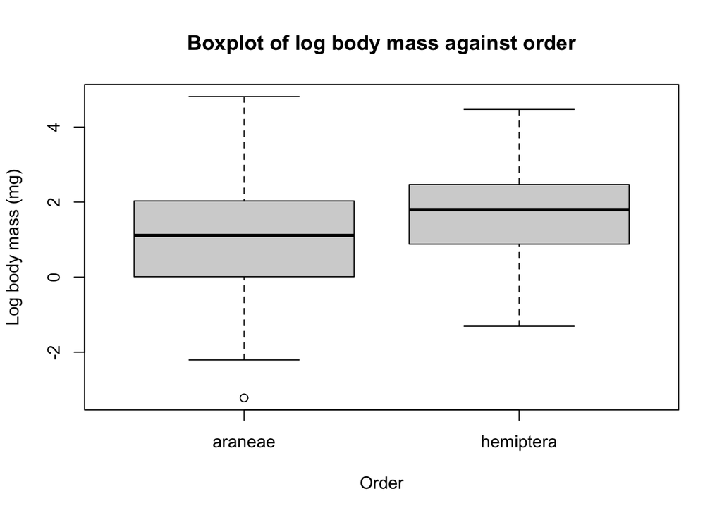

**Figure 4.** Boxplot of the logged body masses (mg) against the order of the arthropods (*araneae* or *hemiptera*).

### Relationship between body mass (numeric) and region (categorical)

The boxplot of the logged body masses of the arthropods against *temperate* and *tropical* regions (Figure 5) suggests that the distribution of logged body masses in each region do not differ much in their medians and ranges (although the median of body masses is slightly larger for temperate regions compared to tropical ones). There does not seem to be any outliers.

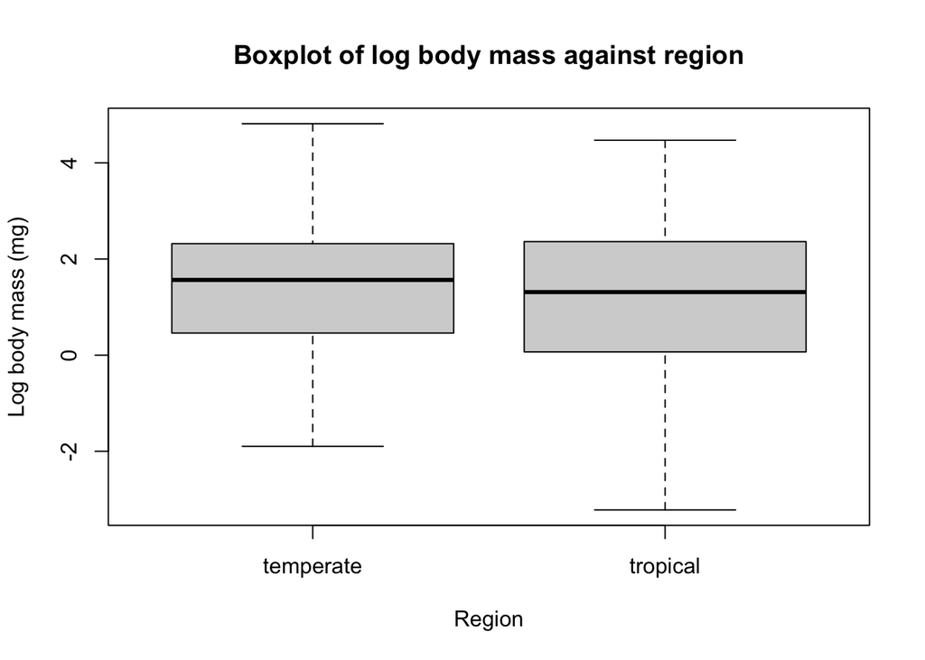

**Figure 5.** Boxplot of the logged body masses (mg) against region (*temperate* or *tropical*).

## Statistical Methods

### Welch’s *t*-test

To compare the means of two groups, we can use the two-sample *t*-test. This allows us to see if the log body masses of arthropods differ between tropical and temperate regions. This test has three assumptions:

- Both groups are random samples.
- Both samples are normally distributed.
- The variances of both samples are equal.

However, when the assumption of equal variance is not met, then we can use Welch’s *t*-test. This test is similar to the two-sample *t*-test, but it also accounts for the unequal variance between the groups.

Now we check the assumptions of the two-sample *t*-test:

- The random sampling assumption is met because the arthropods were randomly sampled from different taxa and regions.
- The normal assumption is tested by running a Shapiro-Wilk test on each of the regions. Running this test shows that the distribution of the logged body masses of arthropods in temperate and tropical regions are not significantly different from a normal distribution ($p = 0.5455$ and $p = 0.1698$, respectively). Therefore, both of these groups are normally distributed.
- The equal variance assumption is tested by running Levene’s test on the two regions. Running this test shows that the variance of the logged body masses of the two regions are significantly different from each other (*p = 0.03223*).

Since the equal variance assumption is not met, we will use Welch’s *t*-test instead. The hypotheses of Welch’s *t* test in the context of this study are as follows:

- $H_0$: The mean of the logged body masses of arthropods is not different for those living in temperate regions compared to tropical regions; $p > 0.05$.
- $H_A$: The mean of the logged body masses of arthropods is different for those living in temperate regions compared to tropical regions; $p \le 0.05$.

### Linear Regression

To predict the value of a numeric variable, we can use linear regression. This allows us to see if the body lengths of the arthropods, their orders, and the region where they reside can predict a change in body mass. This model has three assumptions:

- The sample is random.
- The residuals have equal variance.
- The residuals are normally distributed.

We check the assumptions of linear regression using the three aforementioned predictors:

- The random sampling assumption is met because the arthropods were randomly sampled from different taxa and regions.
- The equal variance assumption is tested by checking for homoscedasticity in the residuals vs. fitted plot (see the “Linear Regression” section under “Statistical Methods” in the Appendix). We should not see any distinct pattern in the points of this plot. For the models with body lengths as a predictor, all of the residuals vs. fitted plots show a curved trend, so we cannot conclude that the equal variance assumption is met. However, when the body lengths is not included in the model (i.e. when the only predictors were order and region), we can see that the plot does not show any distinct pattern - the line of best fit in red is essentially flat. Therefore, the normal assumption is only met when body lengths is not in the model.
- The normal assumption is tested by running a Shapiro-Wilk test on the residuals of the linear model. The residuals for the linear models with body lengths are not normally distributed ($p < 0.05$). However, the model with just order and region as predictors did have normally distributed residuals ($p = 0.78344$).

In summary, the linear model assumptions are only met when order and region (which are both notably categorical) are the only predictors. The hypotheses of this linear model are as follows:

- $H_0$: The coefficient estimates for order and region and the intercept of the regression line are equal to 0; $\beta = 0$.
- $H_A$: The coefficient estimates for order and region and the intercept of the regression line are not equal to 0; $\beta = 0$.

## Results

### Linear Regression

The linear regression model with order and region as predictors is a significant model ($p = 0.0001276$), though its low $R^2$ value of 0.0625 suggests that these two predictors do not provide a good fit for the model. Furthermore, the coefficient estimate for region is not significant ($p = 0.578$), so whether a region is tropical or temperate does not seem to have much of an effect on body mass. However, it is the only model that met all of the linear model assumptions (see Figure 6 below).

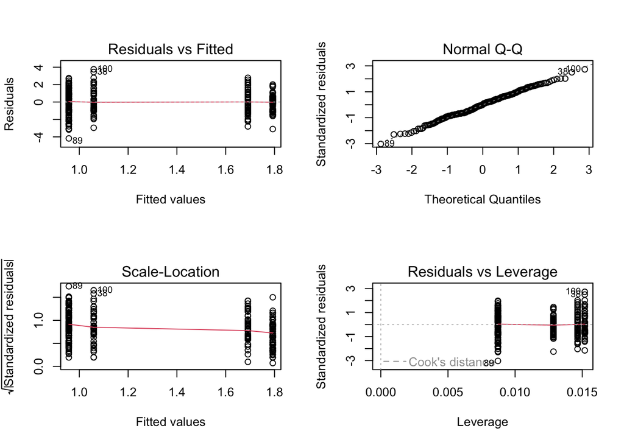

**Figure 6.** Diagnostic plots for the linear model with order and region as the only predictors. The residuals vs. fitted plot shows that there is no distinct pattern in the points. The Q-Q plot shows that the standardized residuals approximately follow a normal distribution.

Although the models with body lengths as a predictor did not meet the equal variance and normal assumptions, it is worthwhile to put the plots here.

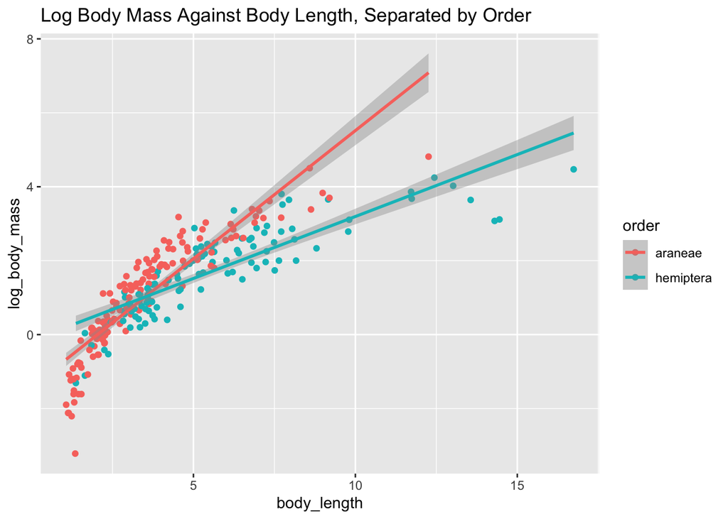

**Figure 7.** Linear regression plot of log body mass against body length, with the different colors representing the orders.

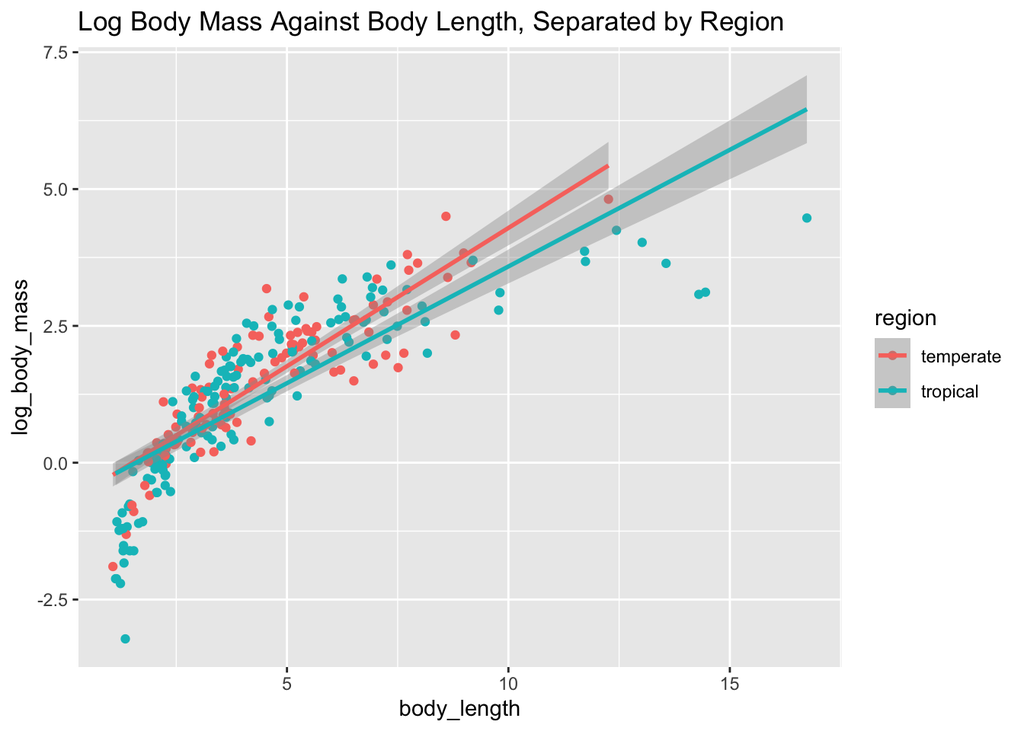

**Figure 8.** Linear regression plot of log body mass against body length, with the different colors representing the regions.

## Discussion

In this study, we found the following results:

- The mean of the logged body masses did not differ between temperate and tropical regions.
- The linear model with order and region as predictors was not a good fit of our data, even though it was the only model that met all of the assumptions.

The main limitation of this study was the amount of observations used. The data used was intentionally subsetted in our to simplify the analysis since using larger sample sizes often led to assumptions of the tests not being met. However, this also means that the results are not as generalizable since less data points were used. As a reference, the original dataset had over 6000 observations and more than 15 orders, whereas this study only used 250 observations and 2 orders.

A future extension of this study could look into using more complicated models. As seen from the plot of body masses against body lengths, the relationship is clearly not linear. Using more complicated models (i.e. regression splines) may be able to fit the data much better since they allow for more flexibility.

## References

Benke, A. C., Huryn, A. D., Smock, L. A., & Wallace, J. B. (1999). Length-Mass Relationships for Freshwater Macroinvertebrates in North America with Particular Reference to the Southeastern United States. *Journal of the North American Benthological Society*, *18*(3), 308–343. https://doi.org/10.2307/1468447

Sohlström, E. H., Marian, L., Barnes, A. D., Haneda, N. F., Scheu, S., Rall, B. C., Brose, U., & Jochum, M. (2018). Applying generalized allometric regressions to predict live body mass of tropical and temperate arthropods. *Ecology and Evolution*, *8*(24), 12737–12749. https://doi.org/10.1002/ece3.4702

## Appendix

### Loading Packages and Data

```r
# load packages
library(tidyverse)
library(knitr)
library(car)
library(psych)

set.seed(1) # keep the random sample the same whenever code is run

arthropods <- read.csv("Sohlstroem_et_al_Data_Dryad.csv", # load this file
                       stringsAsFactors=TRUE)             # w/ strings converted into factors

str(arthropods) # structure of the dataset

order_freqs <- sort(table(arthropods$Order), # sort frequencies of orders
                    decreasing = T)          # in decreasing order

most_common_orders <- names(order_freqs)[1:2] # get the top 2 most frequent orders

arthropods.cleaned <- arthropods %>%                                          # from the dataset
  select(Live.body.mass..mg., Body.length..mm., Order, Geographic.Region) %>% # select these columns
  na.omit() %>%                                                               # omit all NA values
  filter(Order %in% most_common_orders) %>%                                   # only keep rows w/ the top 2 orders
  sample_n(250)                                                               # sample 250 random observations

names(arthropods.cleaned) <- c("body_mass", "body_length", "order", "region") # rename columns
arthropods.cleaned$order <- factor(arthropods.cleaned$order)                  # drops unused levels in order column
arthropods.cleaned$log_body_mass <- log(arthropods.cleaned$body_mass)         # add column of log body masses
```

### Introduction

```r
vars <- cbind(                                                                                                       # make a table called vars
  Variable = c("Body mass (mg)", "Body length (mm)", "Order", "Region"),                                             # w/ column of variables
  Type = c("Numeric", "Numeric", "Categorical (*araneae* / *hemiptera*)", "Categorical (*temperate* / *tropical*)")) # and their types (numeric/categorical)

caption <- "**Table 1.** The variables of interest in this study. The body mass is the response while the rest are predictors. There are 2 numeric variables and 2 categorical variables." # caption


kable(vars,            # output the table vars
      caption=caption, # w/ the caption above
      align="c")       # w/ center alignment
```

### Exploratory Data Analysis

#### Distribution of body masses (numeric)

```r
par(mfrow=c(1, 2)) # 1 row, 2 plots

hist(arthropods.cleaned$body_mass,    # histogram of body masses
     main="Histogram of body masses", # title
     xlab="Log body mass (mg)")       # x-axis label

qqPlot(arthropods.cleaned$body_mass,   # Q-Q plot of body masses
       main="Q-Q plot of body masses", # title
       ylab="Log body mass (mg)")      # y-axis label

shapiro.test(arthropods.cleaned$body_mass) # do the body masses follow a normal distribution?
```

```r
par(mfrow=c(1, 2)) # 1 row, 2 plots

hist(arthropods.cleaned$log_body_mass,     # histogram of log body masses
     main="Histogram of log body masses",  # title
     xlab="Log body mass (mg)")            # x-axis label

qqPlot(arthropods.cleaned$log_body_mass,   # Q-Q plot of log body masses
       main="Q-Q plot of log body masses", # title
       ylab="Log body mass (mg)")          # y-axis label

shapiro.test(arthropods.cleaned$log_body_mass) # do the logged body masses follow a normal distribution?
```

### Relationship between body mass (numeric) and order (categorical)

```r
boxplot(log_body_mass ~ order, data=arthropods.cleaned, # boxplot of logged body masses against order
        main="Boxplot of log body mass against order",  # title
        xlab="Order",                                   # x-axis label
        ylab="Log body mass (mg)")                      # y-axis label
```

### Relationship between body mass (numeric) and region (categorical)

```r
boxplot(log_body_mass ~ region, data=arthropods.cleaned, # boxplot of logged body masses against region
        main="Boxplot of log body mass against region",  # title
        xlab="Region",                                   # x-axis label
        ylab="Log body mass (mg)")                       # y-axis label
```

### Statistical Methods

#### Welch’s *t*-test

```r
temperate <- subset(arthropods.cleaned, region == "temperate") # subset rows in temperate regions
tropical <- subset(arthropods.cleaned, region == "tropical")   # subset rows in tropical regions
```

```r
shapiro.test(temperate$log_body_mass) # Shapiro-Test Wilk test on log body masses in temperate regions
```

```
##
##  Shapiro-Wilk normality test
##
## data:  temperate$log_body_mass
## W = 0.98887, p-value = 0.5455
```

```r
shapiro.test(tropical$log_body_mass)  # Shapiro-Test Wilk test on log body masses in tropical regions
```

```
##
##  Shapiro-Wilk normality test
##
## data:  tropical$log_body_mass
## W = 0.98659, p-value = 0.1698
```

```r
leveneTest(log_body_mass ~ region, data=arthropods.cleaned) # do the two regions have equal variance?
```

```
## Levene's Test for Homogeneity of Variance (center = median)
##        Df F value  Pr(>F)
## group   1  4.6383 0.03223 *
##       248
## ---
## Signif. codes:  0 '***' 0.001 '**' 0.01 '*' 0.05 '.' 0.1 ' ' 1
```

#### Linear Regression

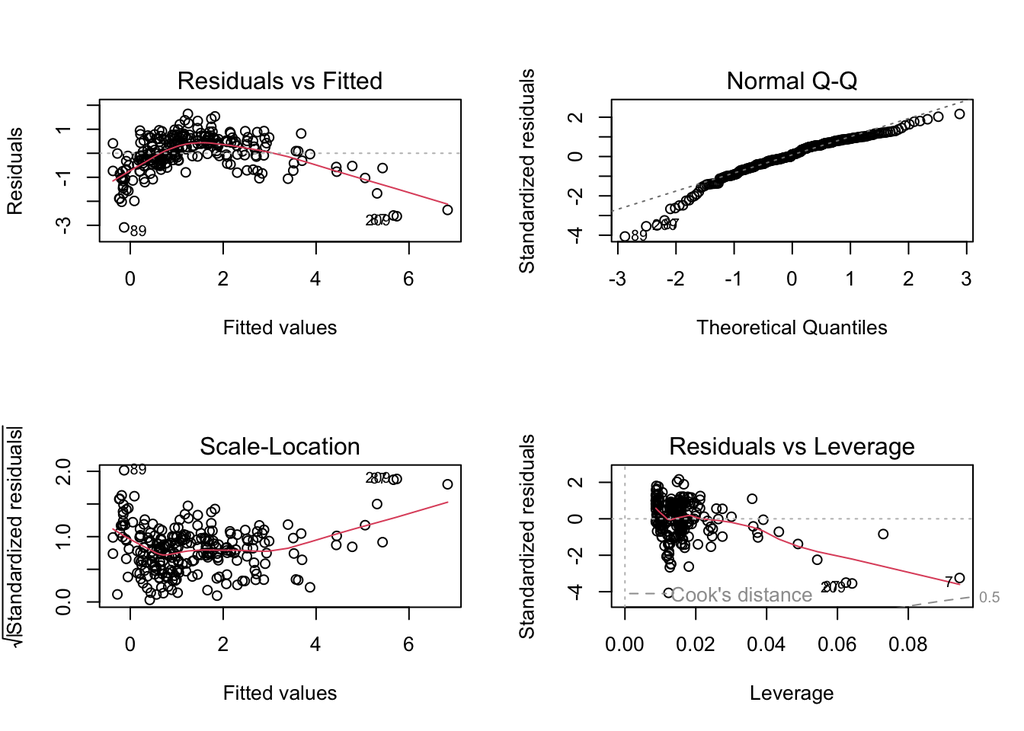

```r
fit1 <- lm(log_body_mass ~ body_length + region + order, data=arthropods.cleaned) # fit 1st model
par(mfrow=c(2, 2))                                                                # 2 rows, 2 plots per row
plot(fit1)                                                                        # diagnostic plots
```

```r
shapiro.test(fit1$residuals) # are the residuals normally distributed?
```

```
##
##  Shapiro-Wilk normality test
##
## data:  fit1$residuals
## W = 0.94786, p-value = 8.601e-08
```

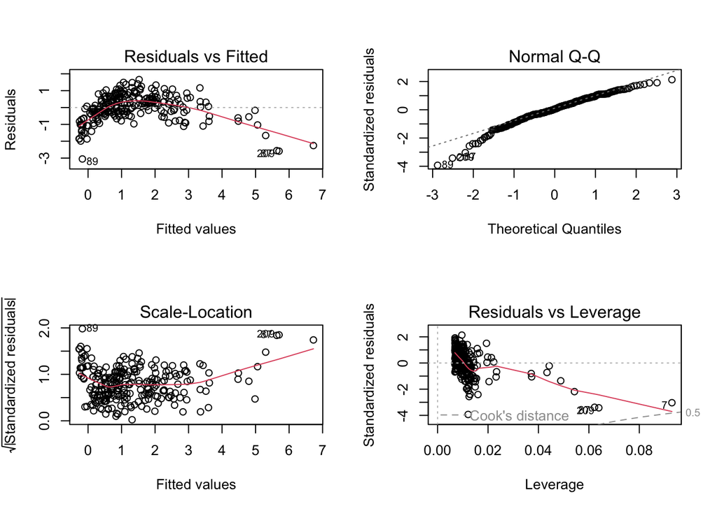

```r
fit2 <- lm(log_body_mass ~ body_length + region, data=arthropods.cleaned) # fit 2nd model
par(mfrow=c(2, 2))                                                        # 2 rows, 2 plots per row
plot(fit2)                                                                # diagnostic plots
```

```r
shapiro.test(fit2$residuals) # diagnostic plots
```

```
##
##  Shapiro-Wilk normality test
##
## data:  fit2$residuals
## W = 0.96747, p-value = 1.819e-05
```

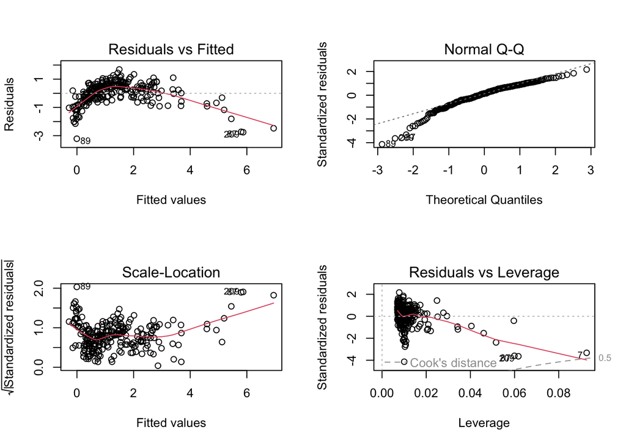

```r
fit3 <- lm(log_body_mass ~ body_length + order, data=arthropods.cleaned) # fit 3rd model
par(mfrow=c(2, 2))                                                       # 2 rows, 2 plots per row
plot(fit3)                                                               # diagnostic plots
```

```r
shapiro.test(fit3$residuals) # are the residuals normally distributed?
```

```
##
##  Shapiro-Wilk normality test
##
## data:  fit3$residuals
## W = 0.93949, p-value = 1.247e-08
```

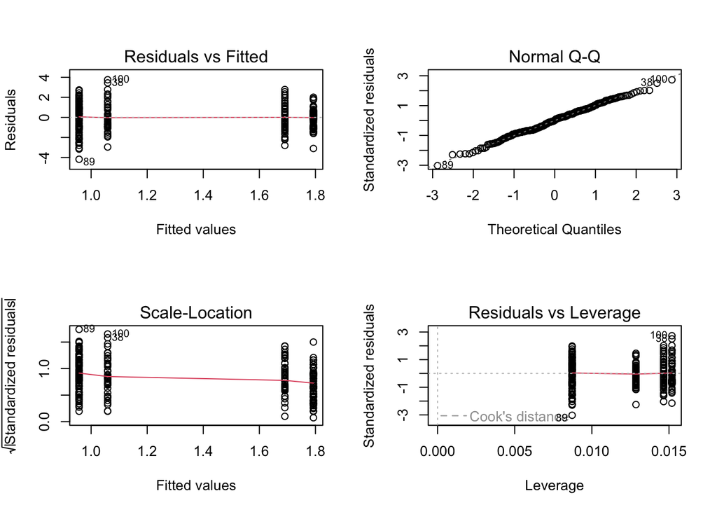

```r
fit4 <- lm(log_body_mass ~ order + region, data=arthropods.cleaned) # fit 4th model
par(mfrow=c(2, 2))                                                  # 2 rows, 2 plots per row
plot(fit4)                                                          # diagnostic plots
```

```r
shapiro.test(fit4$residuals) # are the residuals normally distributed?
```

```
##
##  Shapiro-Wilk normality test
##
## data:  fit4$residuals
## W = 0.99606, p-value = 0.7834
```

### Results

#### Welch’s *t*-test

```r
t.test(log_body_mass ~ region, data=arthropods.cleaned, var.equal=FALSE) # run Welch's t-test
```

```
##
##  Welch Two Sample t-test
##
## data:  log_body_mass by region
## t = 1.5664, df = 244.17, p-value = 0.1186
## alternative hypothesis: true difference in means between group temperate and group tropical is not equal to 0
## 95 percent confidence interval:
##  -0.07130893  0.62512227
## sample estimates:
## mean in group temperate  mean in group tropical
##                1.475269                1.198362
```

#### Linear Regression

```r
summary(fit4) # order and region as predictors
```

```
##
## Call:
## lm(formula = log_body_mass ~ order + region, data = arthropods.cleaned)
##
## Residuals:
##     Min      1Q  Median      3Q     Max
## -4.1760 -0.9441  0.0292  0.9401  3.7554
##
## Coefficients:
##                Estimate Std. Error t value Pr(>|t|)
## (Intercept)      1.0591     0.1708   6.199 2.36e-09 ***
## orderhemiptera   0.7337     0.1824   4.022 7.67e-05 ***
## regiontropical  -0.1019     0.1831  -0.556    0.578
## ---
## Signif. codes:  0 '***' 0.001 '**' 0.01 '*' 0.05 '.' 0.1 ' ' 1
##
## Residual standard error: 1.386 on 247 degrees of freedom
## Multiple R-squared:  0.07003,    Adjusted R-squared:  0.0625
## F-statistic:   9.3 on 2 and 247 DF,  p-value: 0.0001276
```

```r
ggplot(arthropods.cleaned, aes(x = body_length, y = log_body_mass, color = order)) + # formula
  geom_point() +                                                                     # add points
  geom_smooth(method="lm") +                                                         # add regression line
  labs(title = "Log Body Mass Against Body Length, Separated by Order", # title
       xlab = "Body length (mm)",                                       # x-axis label
       ylab = "Log body mass (mg)")                                     # y-axis label
```

```r
ggplot(arthropods.cleaned, aes(x = body_length, y = log_body_mass, color = region)) + # formula
  geom_point() +                                                                      # add points
  geom_smooth(method="lm") +                                                          # add regression line
  labs(title = "Log Body Mass Against Body Length, Separated by Region", # title
       xlab = "Body length (mm)",                                        # x-axis label
       ylab = "Log body mass (mg)")                                      # y-axis label
```